# A story about philosophy data

First, import some useful packages and read raw data as a pandas dataframe.

```python
import numpy as np
import sklearn as sk
import pandas as pd
import matplotlib.pyplot as plt
```

```python
# import data and see the head to get basic infomation
data = pd.read_csv("philosophy_data1.csv")
data.head()
```

|  | title | author | school | sentence_spacy | sentence_str | original_publication_date | corpus_edition_date | sentence_length | sentence_lowered | tokenized_txt | lemmatized_str |
| --- | --- | --- | --- | --- | --- | --- | --- | --- | --- | --- | --- |
| 0 | Plato - Complete Works | Plato | plato | What's new, Socrates, to make you leave your ... | What's new, Socrates, to make you leave your ... | -350 | 1997 | 125 | what's new, socrates, to make you leave your ... | ['what', 'new', 'socrates', 'to', 'make', 'you... | what be new , Socrates , to make -PRON- lea... |
| 1 | Plato - Complete Works | Plato | plato | Surely you are not prosecuting anyone before t... | Surely you are not prosecuting anyone before t... | -350 | 1997 | 69 | surely you are not prosecuting anyone before t... | ['surely', 'you', 'are', 'not', 'prosecuting',... | surely -PRON- be not prosecute anyone before ... |
| 2 | Plato - Complete Works | Plato | plato | The Athenians do not call this a prosecution b... | The Athenians do not call this a prosecution b... | -350 | 1997 | 74 | the athenians do not call this a prosecution b... | ['the', 'athenians', 'do', 'not', 'call', 'thi... | the Athenians do not call this a prosecution ... |
| 3 | Plato - Complete Works | Plato | plato | What is this you say? | What is this you say? | -350 | 1997 | 21 | what is this you say? | ['what', 'is', 'this', 'you', 'say'] | what be this -PRON- say ? |
| 4 | Plato - Complete Works | Plato | plato | Someone must have indicted you, for you are no... | Someone must have indicted you, for you are no... | -350 | 1997 | 101 | someone must have indicted you, for you are no... | ['someone', 'must', 'have', 'indicted', 'you',... | someone must have indict -PRON- , for -PRON- ... |

Using info() to check the datatype and make sure there is no annoying N/A obstruct data manipulation.

```python
data.info()
```

```
<class 'pandas.core.frame.DataFrame'>
RangeIndex: 360808 entries, 0 to 360807
Data columns (total 11 columns):
 #   Column                     Non-Null Count   Dtype
---  ------                     --------------   -----
 0   title                      360808 non-null  object
 1   author                     360808 non-null  object
 2   school                     360808 non-null  object
 3   sentence_spacy             360808 non-null  object
 4   sentence_str               360808 non-null  object
 5   original_publication_date  360808 non-null  int64
 6   corpus_edition_date        360808 non-null  int64
 7   sentence_length            360808 non-null  int64
 8   sentence_lowered           360808 non-null  object
 9   tokenized_txt              360808 non-null  object
 10  lemmatized_str             360808 non-null  object
dtypes: int64(3), object(8)
memory usage: 30.3+ MB
```

Sentence length is the length of sentence string, which comprises space and punctuation.

Tokenized_txt seems to be generated by splitting sentence and removing repeated words. It is the unique words of a sentence. This feature is useful to measure a complexity of a sentence. So I will create a new feature, "n_tokens", represents the number of tokens in a sentence.

```python
token = list(map(eval, data.tokenized_txt))
data['n_tokens'] = list(map(len, token))
data.head()
```

First, we can look at how many authors does a school have.

```python
# get a list of school
school = data.school.unique()
school, len(school)
```

```
(array(['plato', 'aristotle', 'empiricism', 'rationalism', 'analytic',
        'continental', 'phenomenology', 'german_idealism', 'communism',
        'capitalism', 'stoicism', 'nietzsche', 'feminism'], dtype=object),
 13)
```

```
<BarContainer object of 13 artists>
```

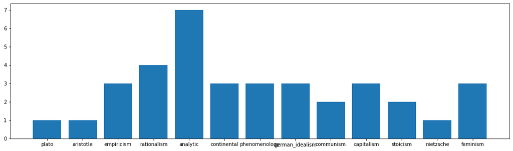

```python
# generate a list of array which comprise authors of each school
sch_author = [data[data.school == school[i]].author.unique() for i in range(13)]

# length of array equals to number of authors
num_of_au = [len(sch_author[i]) for i in range(len(sch_author)) ]

fig1 = plt.figure(figsize=(18,5))
plt.bar(school, num_of_au )
```

Analytic school has the most authors and plato, aristotle and nietzsche only get one. No strange because they are named by authors themselves.

```
<BarContainer object of 36 artists>
```

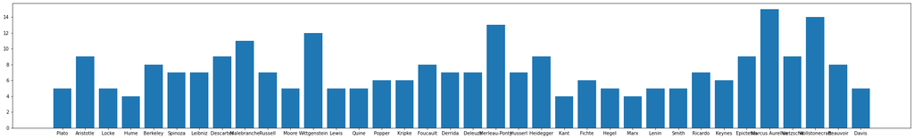

```python
# generate a list comprise author's book title.

au = data.author.unique()
bk_au = [data[data.author == au[i]].title.unique() for i in range(len(au))]
num_of_bk_au = [len(au[i]) for i in range(len(bk_au)) ]
fig2 = plt.figure(figsize=(35,5))
plt.bar(au, num_of_bk_au )
```

Next graph shows how many books each author have.

```
<BarContainer object of 36 artists>
```

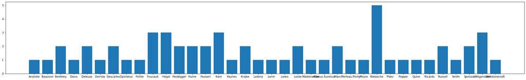

```python
bk_au = data.groupby("author").title.unique().map(len)
fig3 = plt.figure(figsize=(35,5) )
plt.bar(np.sort(au), bk_au )
```

Nietzsche has 5 books, which is the most.

But number of books doesn't not represent the real amount of work by author. Aristotle and Plato both have only one text, which is a collection of all their works. We can show the volume size by adding up "sentence_length" as a rough estimate.

```
<BarContainer object of 36 artists>
```

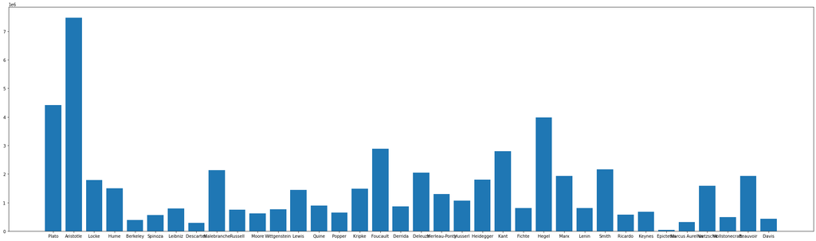

```python
vl_au = [data[data.author == au[i]].sentence_length.sum() for i in range(len(au))]
fig4 = plt.figure(figsize=(35,10))
plt.bar(au, vl_au )
```

```python
au[np.argmax(vl_au)], au[np.argmin(vl_au)]
```

```
('Aristotle', 'Epictetus')
```

Among authors, Aristotle has the most of work and Epictetus has the least.

By the same way, check out the volume of works of different schools.

```
<BarContainer object of 13 artists>
```

[figure not shown]

```python
sch_vol = data.groupby("school").sentence_length.sum()
fig5 = plt.figure(figsize=(21,10))
# plt.bar(range(len(school)), sch_vol )
plt.bar(school, sch_vol )
```

## Popularity

We want to create a index to measure how popular of a school is. A complex and vital theory generally is built by many scholars. If a field has few people working on it, whether it is an acient stuff or it is not that popular. So a popular school should have a certain amount of working (here we represents it by total volume, the sum of sentence length) and have many philosophers interested on it. So we use total volume of school times number of author to measure that popularity.

```
<BarContainer object of 13 artists>
```

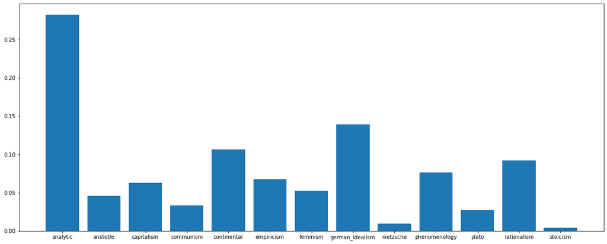

```python
popularity = data.groupby("school").apply(lambda df: df.sentence_length.sum()*len(df.author.unique()) )
popularity = popularity/popularity.sum()  # normalization

fig6 = plt.figure(figsize=(20,8))
plt.bar(np.sort(school), popularity)
```

Analytic school has the most authors and fair amount of works, so it has highest rate of "popularity" in this case. German Idealism, continental and rationalism also perform good, which demonstrates again they are popular modern philosophy genre.

## Difficulty

When people want to study a school of philosophy, difficulty of that is one thing they care about. An obscure book always comprise verbose sentence and uncommon words. So here we try to measure that.

First, we create a dictionary that comprise all the words that those texts use.Raw data has a tokenized_txt. We split it up and combine them together to creat a list of all the words. This step costs several hours.

```python
token = list(map(eval, data.tokenized_txt))
total_words = sum(token,[])

# I saved the output in a csv file.
# with open('total_words_output.csv', 'w',encoding = 'utf-8') as f:
#     f.write(np.str(total_words))
```

There are 9270318 in total, which has a lot repetition of words.

```python
len(total_words)
```

```
9270318
```

Lets introduce FreqDist in nltk, which helps us to get the frequency of each words.The output of FreqDist is a dictionary, and in each element, it comprise the words as key and its frequency integer as value. There are 90332 words appears at least one time.

```python
from nltk.probability import FreqDist
fdist = FreqDist(total_words)

len(fdist)
```

```
90332
```

The most common wors is "the", then by "of", which count a large proportion of whole text words. But we care about rarely appeared words, which is the main barrier to understand text. So, lets sort it by function "most_common()"

```python
fdist
```

```
FreqDist({'the': 660444, 'of': 422626, 'and': 271548, 'to': 260476, 'is': 235136, 'in': 220195, 'that': 175098, 'it': 153145, 'as': 106479, 'be': 94540, ...})
```

```python
common_words_sort = fdist.most_common()
len(common_words_sort)
```

```
90332
```

How to define a common appeared word? I would like to pick 99% of whole words (including repetition) as common words.

```python
num_total_words = len(total_words)
ninety_nine_percent = np.int(num_total_words*0.99)
ninety_nine_percent, num_total_words
```

```
(9177614, 9270318)
```

Our "common_words_sort = fdist.most_common()" has been sorted form the most common words to the least common words. It's a list of tuple. In each tuple, it comprise words and number of frequency. We can add them up to find a threshold that separate common words, which is 99% common, and uncommon words, 1% left.

```python
s = 0
threshold = 0
while (s <= ninety_nine_percent):
    s = s + common_words_sort[threshold][1]
    threshold = threshold + 1
threshold, len(common_words_sort)
```

```
(30000, 90332)
```

So, the threshold is sitting at 30000 from the most common "the". There are still over 60000 words. All of them only counts for 1% percent of total words appear. Imagine how painful when we meet thoe words.

We put the common words together in a list for reference.

```python
not_rare_words_dict = [not_rare_words[i][0] for i in range(len(not_rare_words))]
```

Define a function that take a single tokenized_txt, split it and check if each splited word is in common words dictionary. If it is not in dictionary, we can count it as a rare word (b plus one) and add it in Notions. We will apply this function together with apply() function on column of dataframe.

```python
def count_rarenotion(tokenized_txt):
    Dict=not_rare_words_dict
    b=0
    Notions=[]
    for a in tokenized_txt.strip('"["\'').strip('\']"').split("', '"):
        if a not in Dict:
            Notions.append(a)
            b+=1
    return (b,Notions)
```

Then, apply this on dataframe to create new column. data["Notions"] refers to the rare word in a sentence. data["NumOfNotions"] is the number of rare words in a sentence. This step cost a bit time.

```python
data["Notions"] = data["tokenized_txt"].apply(count_rarenotion) # output is a tuple
data["NumOfNotions"]=data["Notions"].apply(lambda x: x[0])
data["Notions"]=data["Notions"].apply(lambda x: x[1])
data["Notions"]
```

```python
data.head()
```

|  | title | author | school | sentence_spacy | sentence_str | original_publication_date | corpus_edition_date | sentence_length | sentence_lowered | tokenized_txt | lemmatized_str | n_tokens | Notions | NumOfNotions |
| --- | --- | --- | --- | --- | --- | --- | --- | --- | --- | --- | --- | --- | --- | --- |
| 0 | Plato - Complete Works | Plato | plato | What's new, Socrates, to make you leave your ... | What's new, Socrates, to make you leave your ... | -350 | 1997 | 125 | what's new, socrates, to make you leave your ... | ['what', 'new', 'socrates', 'to', 'make', 'you... | what be new , Socrates , to make -PRON- lea... | 23 | [] | 0 |
| 1 | Plato - Complete Works | Plato | plato | Surely you are not prosecuting anyone before t... | Surely you are not prosecuting anyone before t... | -350 | 1997 | 69 | surely you are not prosecuting anyone before t... | ['surely', 'you', 'are', 'not', 'prosecuting',... | surely -PRON- be not prosecute anyone before ... | 12 | [] | 0 |
| 2 | Plato - Complete Works | Plato | plato | The Athenians do not call this a prosecution b... | The Athenians do not call this a prosecution b... | -350 | 1997 | 74 | the athenians do not call this a prosecution b... | ['the', 'athenians', 'do', 'not', 'call', 'thi... | the Athenians do not call this a prosecution ... | 11 | [] | 0 |
| 3 | Plato - Complete Works | Plato | plato | What is this you say? | What is this you say? | -350 | 1997 | 21 | what is this you say? | ['what', 'is', 'this', 'you', 'say'] | what be this -PRON- say ? | 5 | [] | 0 |
| 4 | Plato - Complete Works | Plato | plato | Someone must have indicted you, for you are no... | Someone must have indicted you, for you are no... | -350 | 1997 | 101 | someone must have indicted you, for you are no... | ['someone', 'must', 'have', 'indicted', 'you',... | someone must have indict -PRON- , for -PRON- ... | 19 | [] | 0 |

Then we can count rare words of school and their ratio.

```python
rare_words_by_school = data.groupby("school").NumOfNotions.sum()
rare_words_by_school
```

```
school
analytic           11906
aristotle           7473
capitalism          2613
communism           6036
continental        12956
empiricism          2737
feminism            7801
german_idealism    14933
nietzsche           4644
phenomenology       8537
plato               5108
rationalism         7346
stoicism             622
Name: NumOfNotions, dtype: int64
```

```python
rare_words_school_ratio = rare_words_by_school/len(rare_words)
rare_words_school_ratio = rare_words_school_ratio/sum(rare_words_school_ratio) # normalization
rare_words_school_ratio
```

```
school
analytic           0.128419
aristotle          0.080604
capitalism         0.028184
communism          0.065105
continental        0.139745
empiricism         0.029522
feminism           0.084142
german_idealism    0.161069
nietzsche          0.050091
phenomenology      0.092081
plato              0.055095
rationalism        0.079235
stoicism           0.006709
Name: NumOfNotions, dtype: float64
```

ratio is calculated by number of rare words in a school over number of total rare word. Finaly, we get chart.

```
<BarContainer object of 13 artists>
```

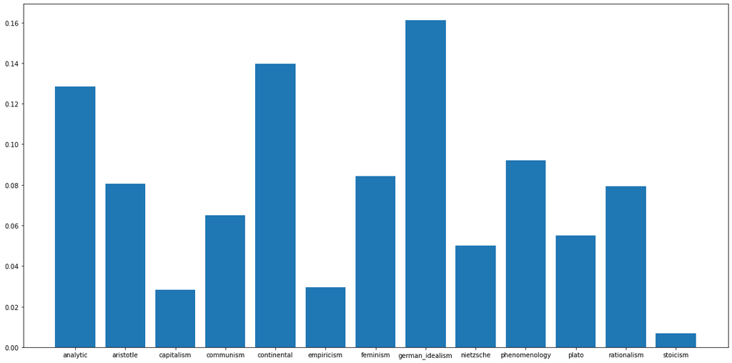

```python
fig7 = plt.figure(figsize = (20,10))
plt.bar(np.sort(school), rare_words_school_ratio)
```

We can see that analytic, continental, german idealism are three top complex school with the most rare words. Modern philosophy comparing to the ancient are relativly difficult to understand.

Now, we add another feature, the length of sentence as a part difficulty. (Long sentence often has many logic components)

```
<BarContainer object of 13 artists>
```

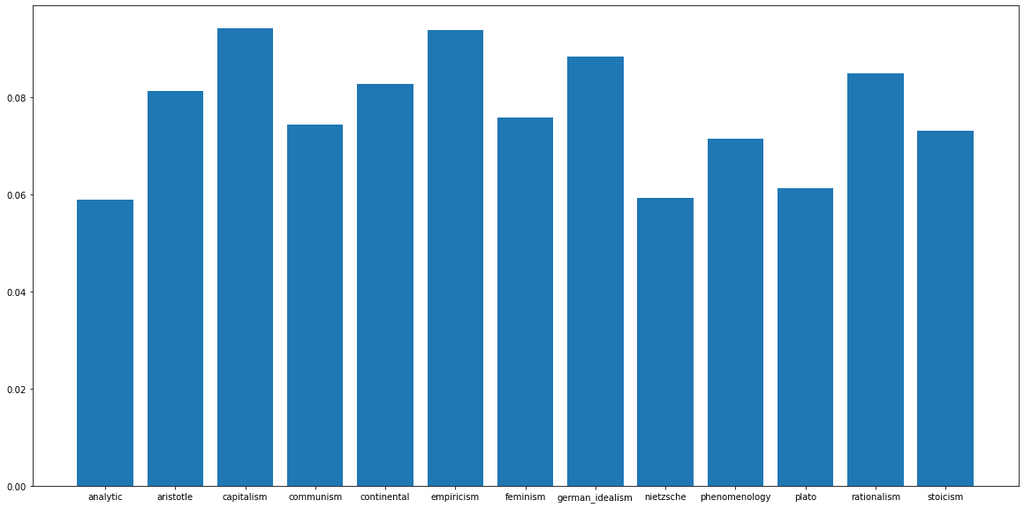

```python
averge_len_school = data.groupby("school").n_tokens.mean()
averge_len_school = averge_len_school/sum(averge_len_school)
averge_len_school

fig8 = plt.figure(figsize = (20,10))
plt.bar(np.sort(school), averge_len_school)
```

There is not much diffierence between. Combine two features with equal weight as a difficulty measurement.

```
<BarContainer object of 13 artists>
```

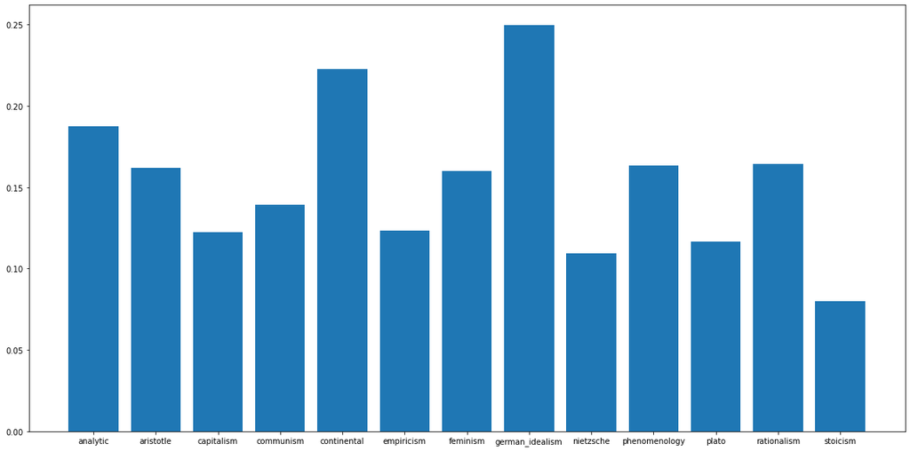

```python
difficulty = averge_len_school + rare_words_school_ratio

fig9 = plt.figure(figsize = (20,10))
plt.bar(np.sort(school), difficulty)
```

We can also use this tool to analyse difficulty by author, which philosophier likes to use rare word most?

```python
rare_words_by_author = data.groupby("author").NumOfNotions.sum()
rare_words_author_ratio = rare_words_by_author/len(rare_words)
rare_words_author_ratio = rare_words_author_ratio/sum(rare_words_author_ratio) # normalization
rare_words_author_ratio
```

```
author
Aristotle          0.080604
Beauvoir           0.058773
Berkeley           0.001855
Davis              0.015467
Deleuze            0.049206
Derrida            0.026404
Descartes          0.001381
Epictetus          0.000582
Fichte             0.006677
Foucault           0.064134
Hegel              0.104301
Heidegger          0.058914
Hume               0.009956
Husserl            0.015403
Kant               0.050091
Keynes             0.006968
Kripke             0.020019
Leibniz            0.026523
Lenin              0.013871
Lewis              0.022597
Locke              0.017711
Malebranche        0.048850
Marcus Aurelius    0.006126
Marx               0.051234
Merleau-Ponty      0.017765
Moore              0.000874
Nietzsche          0.050091
Plato              0.055095
Popper             0.006515
Quine              0.066313
Ricardo            0.001284
Russell            0.003786
Smith              0.019933
Spinoza            0.002481
Wittgenstein       0.008316
Wollstonecraft     0.009902
Name: NumOfNotions, dtype: float64
```

```
<BarContainer object of 36 artists>
```

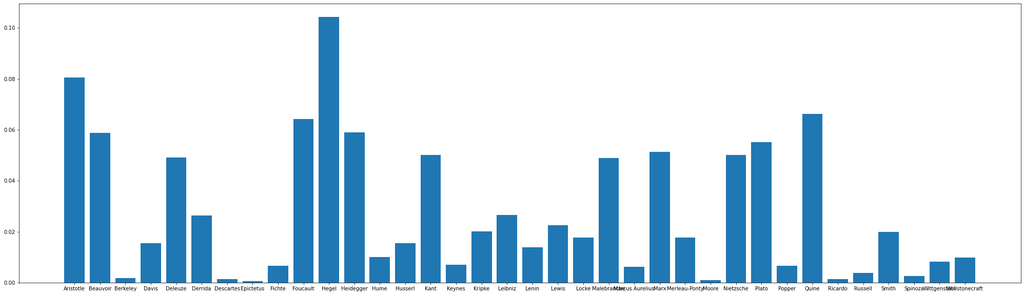

```python
fig10 = plt.figure(figsize = (35,10))
plt.bar(np.sort(au), rare_words_author_ratio)
```

```
<BarContainer object of 36 artists>
```

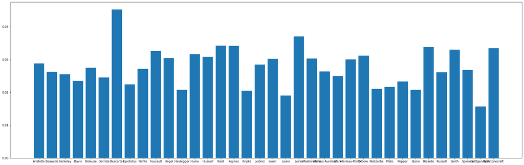

```python
averge_len_author = data.groupby("author").n_tokens.mean()
averge_len_author = averge_len_author/sum(averge_len_author)
averge_len_author

fig11 = plt.figure(figsize = (32,10))
plt.bar(np.sort(au), averge_len_author)
```

```
<BarContainer object of 36 artists>
```

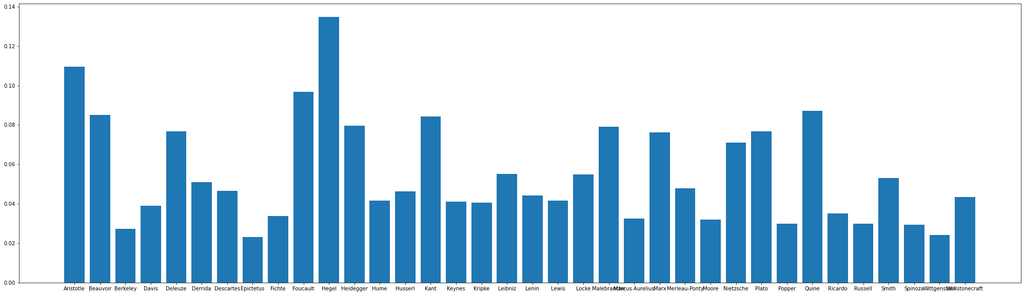

```python
difficulty_by_author = averge_len_author + rare_words_author_ratio

fig12 = plt.figure(figsize = (35,10))
plt.bar(np.sort(au), difficulty_by_author)
```